# scRNAseq-application_dynamo

### **Single Cell Application: Dynamo**

**Instructors:**  
Zongxu Zhang (zongxu.zhang@stu.pku.edu.cn)  
Zexian Zeng (zexianzeng@pku.edu.cn)

**Affiliation:**  
Center for Quantitative Biology  
Academy for Advanced Interdisciplinary Studies  
Peking University

**Lab Website:**  
🔗 http://cqb.pku.edu.cn/zenglab/

> This materials is largely based on [Pancreatic endocrinogenesis differential geometry](https://dynamo-release.readthedocs.io/en/latest/notebooks/tutorial_pancreatic_endocrinogenesis.html), we thank the origional authors for their contribution.

#### **Review of Last Week’s Topics**

Basic scRNA-seq dynamic modeling background

**scVelo**  
A python packages for RNA velocity analysis.

> 💡 **Note:** This course will primarily focus on Python-based workflows for scRNA-seq data analysis.

#### Prerequisite: Creat the enviroment and install packages

1. Create a new enviroment with python

   `conda create --name dynamo python=3.11`
2. Activate the enviroment

   `conda activate dynamo`
3. Install the following packages

   `conda install -c conda-forge dynamo-release` : to install latest version of dynamo

   or, for effeicient installation, using mamba,

   `mamba install -c conda-forge dynamo-release`

   `mamba install scanpy` : to install scanpy for data io

   `pip install matplotlib==3.7.3 scipy==1.13.1` : to install dependicies of dynamo

   `pip install gseapy` : to install GO enrichment package

   If you are using jupyterlab, nb_conda_kernels will automatically register the kernel for you

   `mamba install ipykernel`

```python
# Check python version
!python --version
```

```
Python 3.11.10
```

```python
# Check data exists
# Data collected from https://journals.biologists.com/dev/article/146/12/dev173849/19483/Comprehensive-single-cell-mRNA-profiling-reveals-a
!ls -ll -h /home/zongxu/Misc/lesson/scRNA-application/data/endocrinogenesis_day15.h5ad
```

```
-rw-rw-r-- 1 zongxu zongxu 51M Oct 30  2024 /home/zongxu/Misc/lesson/scRNA-application/data/endocrinogenesis_day15.h5ad
```

```python
# ! source dynamo/bin/activate # in cluster
```

#### Part 1: Import all packages

```python
# Disable annoying warnings
import warnings
warnings.filterwarnings("ignore")

# Import core packages
import dynamo as dyn
import scanpy as sc

import os
os.chdir('/home/zongxu/Misc/lesson/scRNA-application/')

# Adjust visualization
# from IPython.core.display import display, HTML
# display(HTML("<style>.container { width:90% !important; }</style>"))

# Direct show figure in jupyter
%matplotlib inline
```

```python
# check the working dir
os.getcwd()
```

```
'/home/zongxu/Misc/lesson/scRNA-application'
```

```python
# Check dynamo and all dependencies version
dyn.get_all_dependencies_version()
```

| package | umap-learn | typing-extensions | tqdm | statsmodels | setuptools | session-info | seaborn | scipy | scikit-learn | pynndescent | pre-commit | pandas | openpyxl | numpy | numdifftools | numba | networkx | matplotlib | loompy | get-version | dynamo-release | colorcet | anndata |
| --- | --- | --- | --- | --- | --- | --- | --- | --- | --- | --- | --- | --- | --- | --- | --- | --- | --- | --- | --- | --- | --- | --- | --- |
| version | 0.5.6 | 4.12.2 | 4.66.6 | 0.14.4 | 75.1.0 | 1.0.0 | 0.13.2 | 1.13.1 | 1.5.2 | 0.5.13 | 4.0.1 | 2.2.3 | 3.1.5 | 1.23.5 | 0.9.41 | 0.60.0 | 3.4 | 3.7.3 | 3.0.6 | 3.5.5 | 1.3.2 | 3.1.0 | 0.10.9 |

```python
# Set resolution/size, styling and format of figures
dyn.configuration.set_figure_params("dynamo", background="white", figsize=(3, 2))
```

#### Part 2: Data structure and IO

```python
# usually using sc.read_10x_mtx or sc.read_10x_h5
data_path = './data/endocrinogenesis_day15.h5ad'
adata = sc.read_h5ad(data_path)
```

```python
adata
```

```
AnnData object with n_obs × n_vars = 3696 × 27998
    obs: 'clusters_coarse', 'clusters', 'S_score', 'G2M_score'
    var: 'highly_variable_genes'
    uns: 'clusters_coarse_colors', 'clusters_colors', 'day_colors', 'neighbors', 'pca'
    obsm: 'X_pca', 'X_umap'
    layers: 'spliced', 'unspliced'
    obsp: 'distances', 'connectivities'
```

#### Part 3: Preprocess

```python
# known differention related genes in pancreas
pancreas_genes = [
    "Hes1", "Nkx6-1", "Nkx2-2",
    "Neurog3", "Neurod1", "Pax4",
    "Pax6", "Arx", "Pdx1",
    "Ins1", "Ins2", "Ghrl",
    "Ptf1a", "Iapp", "Isl1",
    "Sox9", "Gcg",
]

figure_path = './figure/'
```

```python
# do preprocessing, analog to scanpy
# select 4000 top variavle genes and filter genes that are detected in less than 20 counts (shared)
# ensure all pancrease genes are in the list
dyn.pp.recipe_monocle(adata, n_top_genes=4000,
                      fg_kwargs={"shared_count": 20},
                      genes_to_append=pancreas_genes)
```

```
|-----? dynamo.preprocessing.deprecated is deprecated.
|-----> recipe_monocle_keep_filtered_cells_key is None. Using default value from DynamoAdataConfig: recipe_monocle_keep_filtered_cells_key=True
|-----> recipe_monocle_keep_filtered_genes_key is None. Using default value from DynamoAdataConfig: recipe_monocle_keep_filtered_genes_key=True
|-----> recipe_monocle_keep_raw_layers_key is None. Using default value from DynamoAdataConfig: recipe_monocle_keep_raw_layers_key=True
|-----> apply Monocole recipe to adata...
|-----> ensure all cell and variable names unique.
|-----> ensure all data in different layers in csr sparse matrix format.
|-----> ensure all labeling data properly collapased
|-----> filtering cells...
|-----> 3696 cells passed basic filters.
|-----> filtering gene...
|-----> 6956 genes passed basic filters.
|-----> calculating size factor...
|-----> selecting genes in layer: X, sort method: SVR...
|-----> size factor normalizing the data, followed by log1p transformation.
|-----> Set <adata.X> to normalized data
|-----> applying PCA ...
|-----> <insert> X_pca to obsm in AnnData Object.
|-----> cell cycle scoring...
|-----> computing cell phase...
|-----> [Cell Phase Estimation] completed [14.7689s]
|-----> [Cell Cycle Scores Estimation] completed [0.5184s]
|-----> [recipe_monocle preprocess] completed [8.9682s]
```

#### Part 4: Calculate RNA velocity

```python
# Setting the model into stochastic mode, for cells may not at steady state
dyn.tl.dynamics(adata, model="stochastic")
```

```
|-----> dynamics_del_2nd_moments_key is None. Using default value from DynamoAdataConfig: dynamics_del_2nd_moments_key=False
|-----------> removing existing M layers:[]...
|-----------> making adata smooth...
|-----> calculating first/second moments...
|-----> [moments calculation] completed [19.0082s]
```

```
AnnData object with n_obs × n_vars = 3696 × 27998
    obs: 'clusters_coarse', 'clusters', 'S_score', 'G2M_score', 'nGenes', 'nCounts', 'pMito', 'pass_basic_filter', 'unspliced_Size_Factor', 'initial_unspliced_cell_size', 'Size_Factor', 'initial_cell_size', 'spliced_Size_Factor', 'initial_spliced_cell_size', 'ntr', 'cell_cycle_phase'
    var: 'highly_variable_genes', 'nCells', 'nCounts', 'pass_basic_filter', 'score', 'log_m', 'log_cv', 'frac', 'use_for_pca', 'ntr', 'beta', 'gamma', 'half_life', 'alpha_b', 'alpha_r2', 'gamma_b', 'gamma_r2', 'gamma_logLL', 'delta_b', 'delta_r2', 'bs', 'bf', 'uu0', 'ul0', 'su0', 'sl0', 'U0', 'S0', …
    uns: 'clusters_coarse_colors', 'clusters_colors', 'day_colors', 'neighbors', 'pca', 'pp', 'velocyto_SVR', 'PCs', 'explained_variance_ratio_', 'pca_mean', 'pca_fit', 'feature_selection', 'cell_phase_genes', 'dynamics'
    obsm: 'X_pca', 'X_umap', 'X', 'cell_cycle_scores'
    layers: 'spliced', 'unspliced', 'X_unspliced', 'X_spliced', 'M_u', 'M_uu', 'M_s', 'M_us', 'M_ss', 'velocity_S'
    obsp: 'distances', 'connectivities', 'moments_con'
```

```python
# Dimension reduction, and then calculate UMAP basis
dyn.tl.reduceDimension(adata, n_pca_components=30)
```

```
|-----> retrieve data for non-linear dimension reduction...
|-----? adata already have basis umap. dimension reduction umap will be skipped!
set enforce=True to re-performing dimension reduction.
|-----> [UMAP] completed [0.0044s]
```

```python
# Project high dimensional velocity vectors onto
# UMAP low dimensional embeddings
dyn.tl.cell_velocities(adata, method="pearson", other_kernels_dict={"transform": "sqrt"})
# PCA low dimensional embeddings
dyn.tl.cell_velocities(adata, basis="pca")
```

```
|-----> [calculating transition matrix via pearson kernel with sqrt transform.] in progress: 100.0000%|-----> [calculating transition matrix via pearson kernel with sqrt transform.] completed [2.8709s]
|-----> [projecting velocity vector to low dimensional embedding] in progress: 100.0000%|-----> [projecting velocity vector to low dimensional embedding] completed [0.8823s]
Using existing pearson_transition_matrix found in .obsp.
|-----> [projecting velocity vector to low dimensional embedding] in progress: 100.0000%|-----> [projecting velocity vector to low dimensional embedding] completed [0.8776s]
```

```
AnnData object with n_obs × n_vars = 3696 × 27998
    obs: 'clusters_coarse', 'clusters', 'S_score', 'G2M_score', 'nGenes', 'nCounts', 'pMito', 'pass_basic_filter', 'unspliced_Size_Factor', 'initial_unspliced_cell_size', 'Size_Factor', 'initial_cell_size', 'spliced_Size_Factor', 'initial_spliced_cell_size', 'ntr', 'cell_cycle_phase'
    var: 'highly_variable_genes', 'nCells', 'nCounts', 'pass_basic_filter', 'score', 'log_m', 'log_cv', 'frac', 'use_for_pca', 'ntr', 'beta', 'gamma', 'half_life', 'alpha_b', 'alpha_r2', 'gamma_b', 'gamma_r2', 'gamma_logLL', 'delta_b', 'delta_r2', 'bs', 'bf', 'uu0', 'ul0', 'su0', 'sl0', 'U0', 'S0', …
    uns: 'clusters_coarse_colors', 'clusters_colors', 'day_colors', 'neighbors', 'pca', 'pp', 'velocyto_SVR', 'PCs', 'explained_variance_ratio_', 'pca_mean', 'pca_fit', 'feature_selection', 'cell_phase_genes', 'dynamics', 'grid_velocity_umap', 'grid_velocity_pca'
    obsm: 'X_pca', 'X_umap', 'X', 'cell_cycle_scores', 'velocity_umap', 'velocity_pca'
    layers: 'spliced', 'unspliced', 'X_unspliced', 'X_spliced', 'M_u', 'M_uu', 'M_s', 'M_us', 'M_ss', 'velocity_S'
    obsp: 'distances', 'connectivities', 'moments_con', 'pearson_transition_matrix'
```

```python
# Plot the velocity streamline
dyn.pl.streamline_plot(adata,
                       color=["clusters"],
                       basis="umap",
                       show_legend="on data",
                       show_arrowed_spines=True,
                       save_show_or_return='save',
                       save_kwargs={
                           "prefix": "01_velocity_streamline",  # prefix
                           "ext": "png",                        # file format
                           "path": figure_path,                 # save dir (default current working dir)
                           "dpi": 300,                          # resolution
                           "transparent": True,
                           "close": True,
                           "verbose": True
                       }
                      )
```

```
|-----------> plotting with basis key=X_umap
|-----------> skip filtering clusters by stack threshold when stacking color because it is not a numeric type
Saving figure to ./figure/01_velocity_streamline_dyn_savefig.png...
Done
```

```python
# Plot the velocity vector per cell
dyn.pl.cell_wise_vectors(
    adata,
    color=["clusters"],
    basis="umap",
    show_legend="on data",
    quiver_length=4,
    quiver_size=4,
    figsize=(5, 3),
    show_arrowed_spines=False,
    save_show_or_return='save',
    save_kwargs={
        "prefix": "02_cell_wise_velocity",  # prefix
        "ext": "png",                       # file format
        "path": figure_path,                # save dir (default current working dir)
        "dpi": 300,                         # resolution
        "transparent": True,
        "close": True,
        "verbose": True
    }
)
```

```
|-----> X shape: (3696, 2) V shape: (3696, 2)
|-----------> plotting with basis key=X_umap
|-----------> skip filtering clusters by stack threshold when stacking color because it is not a numeric type
Saving figure to ./figure/02_cell_wise_velocity_dyn_savefig.png...
Done
```

#### Part 5: Learn the vector field

```python
# Setting the progenitor cell types
progenitor = adata.obs_names[adata.obs.clusters.isin(["Ductal"])]
len(progenitor)
```

```
916
```

Then, lets dive into some basic differential geometry

[figure not shown]

```python
# Estimate the vector field
dyn.vf.VectorField(adata, basis="pca", pot_curl_div=True)
dyn.vf.VectorField(adata, basis="umap", pot_curl_div=True)

# Calculate the speed, divergence, accelaration and curl
dyn.vf.speed(adata, basis="pca")
dyn.vf.divergence(adata, basis="pca")
dyn.vf.acceleration(adata, basis="pca")
dyn.vf.curl(adata, basis="umap")
```

```
|-----> VectorField reconstruction begins...
|-----> Retrieve X and V based on basis: PCA.
        Vector field will be learned in the PCA space.
|-----> Learning vector field with method: sparsevfc.
|-----> [SparseVFC] begins...
|-----> Sampling control points based on data velocity magnitude...
|-----> [SparseVFC] completed [0.8785s]
|-----> Running ddhodge to estimate vector field based pseudotime in pca basis...
|-----> graphizing vectorfield...
|-----> incomplete neighbor graph info detected: connectivities and distances do not exist in adata.obsp, indices not in adata.uns.neighbors.
|-----> Neighbor graph is broken, recomputing....
|-----> Start computing neighbor graph...
|-----------> X_data is None, fetching or recomputing...
|-----> fetching X data from layer:None, basis:pca
|-----> method arg is None, choosing methods automatically...
|-----------> method ball_tree selected
|-----------? nbrs_idx argument is ignored and recomputed because nbrs_idx is not None and return_nbrs=True
|-----------> calculating neighbor indices...
|-----> [ddhodge completed] completed [17.1179s]
|-----> Computing divergence...
```

```
|-----> [VectorField] completed [18.6889s]
|-----> VectorField reconstruction begins...
|-----> Retrieve X and V based on basis: UMAP.
        Vector field will be learned in the UMAP space.
|-----> Generating high dimensional grids and convert into a row matrix.
|-----> Learning vector field with method: sparsevfc.
|-----> [SparseVFC] begins...
|-----> Sampling control points based on data velocity magnitude...
|-----> [SparseVFC] completed [4.5763s]
|-----> Running ddhodge to estimate vector field based pseudotime in umap basis...
|-----> graphizing vectorfield...
|-----------? nbrs_idx argument is ignored and recomputed because nbrs_idx is not None and return_nbrs=True
|-----------> calculating neighbor indices...
|-----> [ddhodge completed] completed [12.7519s]
|-----> Computing curl...
```

```
|-----> Computing divergence...
```

```
|-----> [VectorField] completed [18.0159s]
```

```
|-----> [Calculating acceleration] in progress: 100.0000%|-----> [Calculating acceleration] completed [0.1980s]
```

```
|-----> X shape: (3696, 2) V shape: (3696, 2)
|-----------> plotting with basis key=X_umap
|-----------> plotting with basis key=X_umap
|-----------> plotting with basis key=X_umap
|-----------> plotting with basis key=X_umap
```

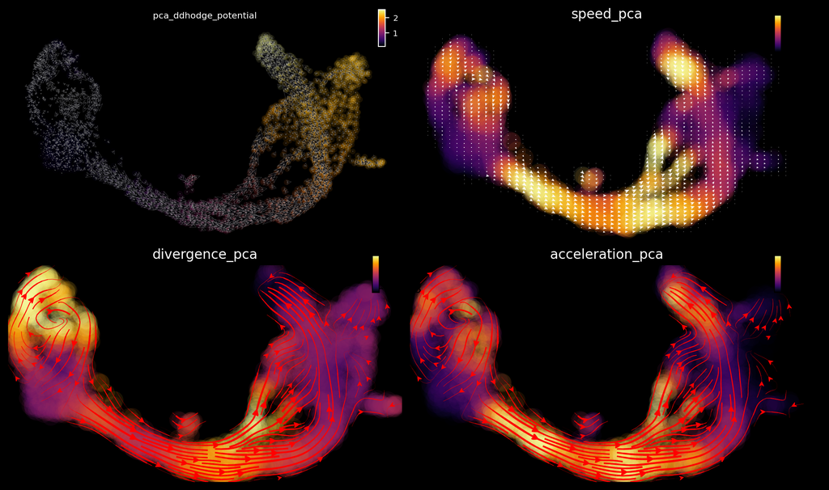

```python
# Draw figures
dyn.configuration.set_figure_params("dynamo", background="black")

import matplotlib.pyplot as plt

fig1, fig1_axes = plt.subplots(ncols=2, nrows=2, constrained_layout=True, figsize=(10, 6))
dyn.pl.cell_wise_vectors(
    adata,
    color="pca_ddhodge_potential",
    pointsize=0.1,
    alpha=0.7,
    ax=fig1_axes[0, 0],
    quiver_length=6,
    quiver_size=6,
    save_show_or_return="return",
    background="black",
)
dyn.pl.grid_vectors(
    adata,
    color="speed_pca",
    basis="umap",
    ax=fig1_axes[0, 1],
    quiver_length=12,
    quiver_size=12,
    save_show_or_return="return",
    background="black",
)
dyn.pl.streamline_plot(
    adata, color="divergence_pca", basis="umap", ax=fig1_axes[1, 0], save_show_or_return="return", background="black"
)
dyn.pl.streamline_plot(
    adata, color="acceleration_pca", basis="umap", ax=fig1_axes[1, 1], save_show_or_return="return", background="black"
)

fig1.savefig('./figure/03_combined_plots.png')
plt.show()
```

The acceleration and divergence accurately highlight hotspots, including a saddle point in ductal cells (negative divergence), exit from this state to early endocrine progenitors (high positive acceleration), the bifurcation point for late progenitors to differentiate into stable cell types (high acceleration and positive divergence), and stable cell types (negative divergence).

```python
# Draw the potential cell states
dyn.pl.topography(
    adata,
    basis="umap",
    background="white",
    color=["clusters"],
    streamline_color="black",
    show_legend="on data",
    save_show_or_return='save',
    save_kwargs={
        "prefix": "04_cell_state",  # prefix
        "ext": "png",                       # file format
        "path": figure_path,                       # save dir (default current working dir)
        "dpi": 300,                         # resolution
        "transparent": True,
        "close": True,
        "verbose": True
    }
)
```

```
|-----> Vector field for umap is but its topography is not mapped. Mapping topography now ...
|-----------> plotting with basis key=X_umap
|-----------> skip filtering clusters by stack threshold when stacking color because it is not a numeric type
Saving figure to ./figure/04_cell_state_dyn_savefig.png...
Done
```

```python
# Draw the state transition map
dyn.configuration.set_figure_params("dynamo", background="white")
dyn.pd.state_graph(adata, group='clusters', basis='pca', method='vf')
dyn.pl.state_graph(adata,
                   color=['clusters'],
                   group='clusters',
                   basis='umap',
                   show_legend='on data',
                   method='vf',
                   save_show_or_return='save',
                   save_kwargs={
                       "prefix": "05_cell_state_transition_map",  # prefix
                       "ext": "png",                       # file format
                       "path": figure_path,                       # save dir (default current working dir)
                       "dpi": 300,                         # resolution
                       "transparent": True,
                       "close": True,
                       "verbose": True
                   }
                  )
```

```
|-----> Estimating the transition probability between cell types...
|-----> Applying vector field
|-----> [KDTree parameter preparation computation] in progress: 0.0000%|-----> [KDTree computation] completed [0.0013s]
|-----> [iterate groups] in progress: 12.5000%
```

```
uniformly sampling points along a trajectory: 100%|██████████| 100/100 [00:00<00:00, 167.09it/s]
```

```
|-----> [iterate groups] in progress: 25.0000%
```

```
uniformly sampling points along a trajectory: 100%|██████████| 100/100 [00:00<00:00, 165.62it/s]
```

```
|-----> [iterate groups] in progress: 37.5000%
```

```
uniformly sampling points along a trajectory: 100%|██████████| 100/100 [00:00<00:00, 163.19it/s]
```

```
|-----> [iterate groups] in progress: 50.0000%
```

```
uniformly sampling points along a trajectory: 100%|██████████| 100/100 [00:00<00:00, 176.82it/s]
```

```
|-----> [iterate groups] in progress: 62.5000%
```

```
uniformly sampling points along a trajectory: 100%|██████████| 70/70 [00:00<00:00, 161.26it/s]
```

```
|-----> [iterate groups] in progress: 75.0000%
```

```
uniformly sampling points along a trajectory: 100%|██████████| 100/100 [00:00<00:00, 170.83it/s]
```

```
|-----> [iterate groups] in progress: 87.5000%
```

```
uniformly sampling points along a trajectory: 100%|██████████| 100/100 [00:00<00:00, 171.84it/s]
```

```
|-----> [iterate groups] in progress: 100.0000%
```

```
uniformly sampling points along a trajectory: 100%|██████████| 100/100 [00:00<00:00, 158.84it/s]
```

```
|-----> [iterate groups] completed [45.8847s]
|-----> [State graph estimation] completed [0.0015s]
|-----------> plotting with basis key=X_umap
|-----------> skip filtering clusters by stack threshold when stacking color because it is not a numeric type
Saving figure to ./figure/05_cell_state_transition_map_dyn_savefig.png...
Done
```